# Regression Analysis with Lasso Penalty

Po-Hsien Huang

In this example, we will show how to use `lslx` to conduct regression analysis with lasso penalty.

## Data Generation

The following code is used to generate data for regression analysis.

```r
set.seed(9487)
x <- matrix(rnorm(2000), 200, 10)
colnames(x) <- paste0("x", 1:10)
y <- matrix(rnorm(200), 200, 1)
data_reg <- data.frame(y, x)
```

The data set contains 200 observation on 10 covariates (`x1` - `x10`) and a response variable (`y`). By the construction of the data, the 10 covariates are not useful to predict the response. The data is stored in a `data.frame` named `data_reg`.

## Model Specification

Model specification in `lslx` is quite similar to that in `lavaan`. However, different operators and prefix are used to accommodate the presence of penalized parameters. In the following specification, `y` is predicted by `x1` - `x10`.

```r
model_reg <- "y <= x1 + x2 + x3 + x4
              y <~ x5 + x6 + x7 + x8 + x9 + x10"
```

The operator `<=` means that the regression coefficients from the RHS variables to the LHS variables are freely estimated. On the other hand, the operator `<~` means that the regression coefficients from the RHS variables to the LHS variables are estimated with penalty. Details of model syntax can be found in the section of Model Syntax via `?lslx`. After version 0.6.3, `lslx` also support basic `lavaan` operators, including `=~`, `~`, and `~~`.

## Object Initialization

`lslx` is written as an `R6` class. Every time we conduct analysis with `lslx`, an `lslx` object must be initialized. The following code initializes an `lslx` object named `lslx_reg`.

```r
library(lslx)
lslx_reg <- lslx$new(model = model_reg, data = data_reg)
```

```
An 'lslx' R6 class is initialized via 'data' argument.
  Response Variables: y x1 x2 x3 x4 x5 x6 x7 x8 x9 x10
```

## Model Fitting

After an `lslx` object is initialized, method `$fit()` can be used to fit the specified model into the given data.

```r
lslx_reg$fit(penalty_method = "lasso", lambda_grid = seq(.00, .30, .01))
```

```
CONGRATS: Algorithm converges under EVERY specified penalty level.
  Specified Tolerance for Convergence: 0.001
  Specified Maximal Number of Iterations: 100
```

The fitting process requires users to specify the penalty method (argument `penalty_method`) and the considered penalty levels (argument `lambda_grid`). In this example, the `lasso` penalty is implemented on the lambda grid `seq(.00, .30, .01)`. All the fitting result will be stored in the `fitting` field of `lslx_reg`.

## Model Summarizing

Unlike traditional SEM analysis, `lslx` fit the model into data under all the penalty levels considered. To summarize the fitting result, a selector to determine an optimal penalty level must be specified. Available selectors can be found in the section of Penalty Level Selection via `?lslx`. The following code summarize the fitting result under the penalty level selected by Akaike information criterion (AIC).

```r
lslx_reg$summarize(selector = "aic")
```

```
General Information
   number of observations                                200
   number of complete observations                       200
   number of missing patterns                           none
   number of groups                                        1
   number of responses                                    11
   number of factors                                       0
   number of free coefficients                            71
   number of penalized coefficients                        6

Numerical Conditions
   selected lambda                                     0.300
   selected delta                                       none
   selected step                                        none
   objective value                                     0.011
   objective gradient absolute maximum                 0.000
   objective Hessian convexity                         0.778
   number of iterations                                6.000
   loss value                                          0.011
   number of non-zero coefficients                    71.000
   degrees of freedom                                  6.000
   robust degrees of freedom                           5.734
   scaling factor                                      0.956

Fit Indices
   root mean square error of approximation (rmsea)     0.000
   comparative fit index (cfi)                         1.000
   non-normed fit index (nnfi)                         1.000
   standardized root mean of residual (srmr)           0.012

Likelihood Ratio Test
                    statistic         df    p-value
   unadjusted           2.279      6.000      0.892
   mean-adjusted        2.384      6.000      0.881

Root Mean Square Error of Approximation Test
                     estimate      lower      upper
   unadjusted           0.000      0.000      0.057
   mean-adjusted        0.000      0.000      0.058

```

[output cut: 74 more lines]

```
x10<->x10     free     0.991      0.087   11.369    0.000  0.821  1.162

  Intercept
              type  estimate  std.error  z-value  P(>|z|)  lower  upper
     y<-1     free    -0.002      0.073   -0.034    0.973 -0.146  0.141
    x1<-1     free    -0.033      0.078   -0.424    0.671 -0.185  0.119
    x2<-1     free    -0.083      0.076   -1.083    0.279 -0.232  0.067
    x3<-1     free     0.072      0.072    1.001    0.317 -0.069  0.213
    x4<-1     free    -0.025      0.071   -0.353    0.724 -0.164  0.114
    x5<-1     free    -0.050      0.073   -0.683    0.494 -0.194  0.094
    x6<-1     free    -0.096      0.073   -1.321    0.187 -0.238  0.046
    x7<-1     free     0.027      0.065    0.414    0.679 -0.100  0.154
    x8<-1     free     0.048      0.070    0.680    0.496 -0.090  0.185
    x9<-1     free     0.001      0.071    0.016    0.988 -0.139  0.141
   x10<-1     free     0.024      0.070    0.346    0.729 -0.114  0.162
```

In this example, we can observe that all of the penalized coefficients are identified as zero, which is consistent with their population values. The `$summarize()` method also shows the result of significance tests for the coefficients. In `lslx`, the default standard errors are calculated based on a sandwich formula whenever raw data is available. It is generally valid even when the model is misspecified and the data is not normal distributed. However, it may not be valid after selecting an optimal penalty level.

## Visualization

`lslx` provides four methods for visualizing the fitting results. The method `$plot_numerical_condition()` shows the numerical condition under all the penalty levels. The following code plots the values of `n_iter_out` (number of iterations in outer loop), `objective_gradient_abs_max` (maximum of absolute value of gradient of objective function), and `objective_hessian_convexity` (minimum of univariate approximate hessian). The plot can be used to evaluate the quality of numerical optimization. `n_iter_out` shows that the algorithm converges quickly under all the penalty levels. `objective_gradient_abs_max` and `objective_hessian_convexity` indicate that the obtained coefficients are valid minimizers under all the penalty levels.

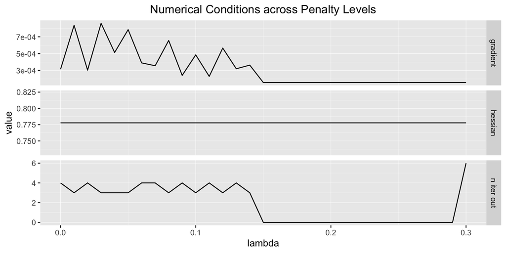

```r
lslx_reg$plot_numerical_condition()
```

The method `$plot_information_criterion()` shows the values of information criteria under all the penalty levels. The plot shows that an optimal value of lambda is any value larger than `0.15`.

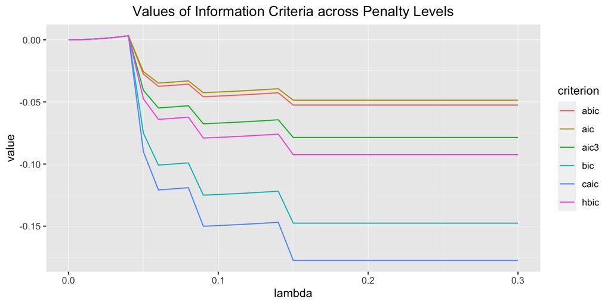

```r
lslx_reg$plot_information_criterion()
```

The method `$plot_fit_index()` shows the values of fit indices under all the penalty levels.

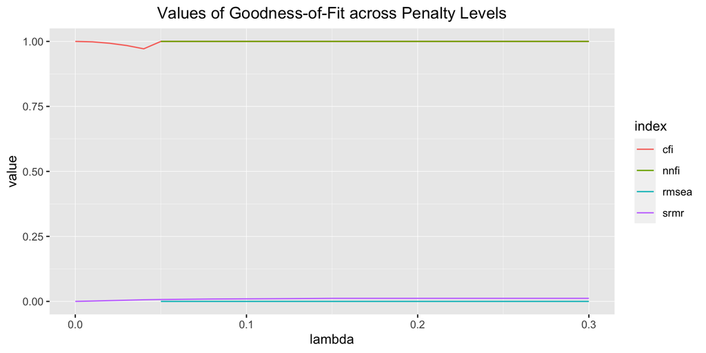

```r
lslx_reg$plot_fit_index()
```

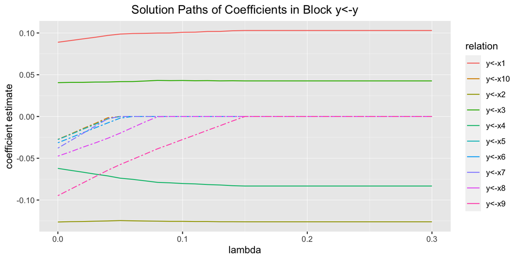

```r
lslx_reg$plot_coefficient(block = "y<-y")
```

## Objects Extraction

In `lslx`, many quantities related to SEM can be extracted by extract-related method. For example, the coefficient under the penalty level selected by `aic` can be obtained by

```r
lslx_reg$extract_coefficient(selector = "aic")
```

```
     y<-1/g     x1<-1/g     x2<-1/g     x3<-1/g     x4<-1/g     x5<-1/g     x6<-1/g     x7<-1/g
   -0.00246    -0.03294    -0.08263     0.07199    -0.02508    -0.05018    -0.09601     0.02681
    x8<-1/g     x9<-1/g    x10<-1/g     y<-x1/g     y<-x2/g     y<-x3/g     y<-x4/g     y<-x5/g
    0.04775     0.00111     0.02436     0.10295    -0.12607     0.04261    -0.08325     0.00000
    y<-x6/g     y<-x7/g     y<-x8/g     y<-x9/g    y<-x10/g     y<->y/g   x1<->x1/g   x2<->x1/g
    0.00000     0.00000     0.00000     0.00000     0.00000     1.10413     1.20623     0.10137
  x3<->x1/g   x4<->x1/g   x5<->x1/g   x6<->x1/g   x7<->x1/g   x8<->x1/g   x9<->x1/g  x10<->x1/g
    0.07090     0.16763     0.06901    -0.28053    -0.05460     0.08263    -0.08223    -0.02676
  x2<->x2/g   x3<->x2/g   x4<->x2/g   x5<->x2/g   x6<->x2/g   x7<->x2/g   x8<->x2/g   x9<->x2/g
    1.16395     0.04209    -0.01149     0.01977    -0.14231     0.03125     0.01724     0.01193
 x10<->x2/g   x3<->x3/g   x4<->x3/g   x5<->x3/g   x6<->x3/g   x7<->x3/g   x8<->x3/g   x9<->x3/g
   -0.04697     1.03474    -0.05058    -0.09476     0.08204     0.07300    -0.11996     0.00334
 x10<->x3/g   x4<->x4/g   x5<->x4/g   x6<->x4/g   x7<->x4/g   x8<->x4/g   x9<->x4/g  x10<->x4/g
   -0.06150     1.00961     0.07830     0.01525    -0.05398     0.17313     0.10138     0.02669
  x5<->x5/g   x6<->x5/g   x7<->x5/g   x8<->x5/g   x9<->x5/g  x10<->x5/g   x6<->x6/g   x7<->x6/g
    1.07833    -0.09960    -0.13574     0.12568    -0.06061     0.07054     1.05658     0.01436
  x8<->x6/g   x9<->x6/g  x10<->x6/g   x7<->x7/g   x8<->x7/g   x9<->x7/g  x10<->x7/g   x8<->x8/g
    0.03514     0.02572    -0.01691     0.83915    -0.08207    -0.01792    -0.09597     0.98588
  x9<->x8/g  x10<->x8/g   x9<->x9/g  x10<->x9/g x10<->x10/g
   -0.11069     0.15616     1.02161    -0.14454     0.99144
```

Here, `/g` means the coefficient belongs to the group `g` which is default group name. We may also check the quality of optimization by viewing the subgradient of objective function

```r
lslx_reg$extract_objective_gradient(selector = "aic", type = "effective")
```

```
                 [,1]
y<-1/g      -5.27e-06
x1<-1/g      0.00e+00
x2<-1/g      0.00e+00
x3<-1/g      2.65e-23
x4<-1/g     -5.29e-23
x5<-1/g     -5.54e-24
x6<-1/g      0.00e+00
x7<-1/g      0.00e+00
x8<-1/g     -3.99e-23
x9<-1/g     -8.87e-24
x10<-1/g    -4.43e-24
y<-x1/g      2.98e-05
y<-x2/g      1.18e-04
y<-x3/g      1.37e-05
y<-x4/g      1.57e-04
y<->y/g      9.45e-06
x1<->x1/g    3.69e-18
x2<->x1/g   -2.88e-18
x3<->x1/g    2.06e-18
x4<->x1/g    9.54e-18
x5<->x1/g   -3.47e-18
x6<->x1/g   -1.30e-17
x7<->x1/g    1.65e-17
x8<->x1/g    1.73e-18
x9<->x1/g   -3.47e-18
x10<->x1/g   0.00e+00
x2<->x2/g   -3.55e-18
x3<->x2/g    3.58e-18
x4<->x2/g   -1.13e-17
x5<->x2/g    4.34e-18
x6<->x2/g   -1.56e-17
x7<->x2/g   -1.73e-18
x8<->x2/g    1.21e-17
x9<->x2/g    1.73e-17
x10<->x2/g   0.00e+00
x3<->x3/g    7.47e-18
x4<->x3/g    1.73e-17
x5<->x3/g    6.07e-18
x6<->x3/g   -2.13e-17
```

[output cut: 17 more lines]

```
x6<->x6/g   -5.71e-18
x7<->x6/g    5.51e-18
x8<->x6/g    7.03e-18
x9<->x6/g   -3.98e-18
x10<->x6/g   1.36e-17
x7<->x7/g    3.41e-17
x8<->x7/g   -8.55e-18
x9<->x7/g    1.83e-17
x10<->x7/g   1.63e-17
x8<->x8/g   -3.43e-17
x9<->x8/g   -1.93e-17
x10<->x8/g   6.20e-18
x9<->x9/g   -2.68e-18
x10<->x9/g  -8.24e-18
x10<->x10/g  1.01e-18
```

Here, the `type` argument is used to specify which types of parameters are used to calculate related quantities. `type = "effective"` indicates that only freely estimated and penalized non-zero parameters are used. By default, `type = "all"`. The subgradient shows that the obtained solution is optimal since all the elements are very small.